# Exercise - Working with Pandas and Seaborn

Now it's your turn to practice what we learned in the previous notebook.

Import the real estate dataset from the following Github path: `data/2017_StPaul_MN_Real_Estate.csv`

**Local Jupyter:** You can use the relative path `../data/2017_StPaul_MN_Real_Estate.csv` to import it.

**Colab:** You will need to upload this file into your Colab container first. Upload `2017_StPaul_MN_Real_Estate.csv` file to the content folder of Colab.

Call this DataFrame `houses`. Remember to import pandas first.

```python
# Your code goes here
import pandas as pd
houses = pd.read_csv("2017_StPaul_MN_Real_Estate.csv")
```

How many rows and columns are there in this dataset?

```python
# Your code goes here
houses.shape
```

```
(5000, 74)
```

Use the `.format()` method on string to print a readable text based on this info. Here is an example:

```
a = 10
print("The value of a is {} hence a * 3 becomes {}.".format(a, a*3))
```

> The value of a is 10 hence a * 3 becomes 30.

```python
# Your code goes here
print("There are {} rows and {} columns.".format(houses.shape[0], houses.shape[1]))
```

```
There are 5000 rows and 74 columns.
```

This dataset has too many columns to study. To start, let's create a new dataset with a smaller number of attributes. To do this, use the following list, `subset_columns`:

```python
subset_columns = ['streetaddress','STREETNAME', 'PostalCode', 'StateOrProvince', 'City', 'SchoolDistrictNumber',
                  'SalesClosePrice', 'LISTDATE', 'offmarketdate', 'LISTPRICE', 'LISTTYPE',
                  'OriginalListPrice', 'PricePerTSFT', 'DAYSONMARKET', 'ROOF',
                  'SQFTABOVEGROUND', 'RoomArea1', 'YEARBUILT']
```

Using the list above create a new DataFrame called `df` that includes the columns specified. One can subset the columns by simply passing a list of the columns to the DataFrame, e.g., `DF[['col1', 'col2']]`. Have in mind that ['col1', 'col2'] was defined in the previous cell, so you can just use it:

```python
# Your code goes here
df = houses[subset_columns]
```

Check the number of rows and columns on `df`:

```python
# Your code goes here
print("There are {} rows and {} columns.".format(df.shape[0], df.shape[1]))
```

```
There are 5000 rows and 18 columns.
```

Let's have a look at the first few rows of `df`:

```python
# Your code goes here
df.head(3)
```

|  | streetaddress | STREETNAME | PostalCode | StateOrProvince | City | SchoolDistrictNumber | SalesClosePrice | LISTDATE | offmarketdate | LISTPRICE | LISTTYPE | OriginalListPrice | PricePerTSFT | DAYSONMARKET | ROOF | SQFTABOVEGROUND | RoomArea1 | YEARBUILT |
| --- | --- | --- | --- | --- | --- | --- | --- | --- | --- | --- | --- | --- | --- | --- | --- | --- | --- | --- |
| 0 | 11511 Stillwater Blvd N | Stillwater | 55042 | MN | LELM - Lake Elmo | 834 - Stillwater | 143000 | 7/15/2017 0:00 | 7/30/2017 0:00 | 139900 | Exclusive Right | 139900 | 145.9184 | 10 | NaN | 980 | 16 x 13 | 1950 |
| 1 | 11200 31st St N | 31st | 55042 | MN | LELM - Lake Elmo | 834 - Stillwater | 190000 | 10/9/2017 0:00 | 10/13/2017 0:00 | 210000 | Exclusive Right | 210000 | 85.2783 | 4 | Asphalt Shingles, Pitched, Age 8 Years or Less | 1268 | 22x14 | 1971 |
| 2 | 8583 Stillwater Blvd N | Stillwater | 55042 | MN | LELM - Lake Elmo | 622 - North St Paul-Maplewood | 225000 | 6/26/2017 0:00 | 7/24/2017 0:00 | 225000 | Exclusive Right | 225000 | 204.1742 | 28 | NaN | 1102 | 20x13 | 1949 |

Use `describe()` to get a high level summary of the data:

```python
# Your code goes here
df.describe()
```

|  | PostalCode | SalesClosePrice | LISTPRICE | OriginalListPrice | PricePerTSFT | DAYSONMARKET | SQFTABOVEGROUND | YEARBUILT |
| --- | --- | --- | --- | --- | --- | --- | --- | --- |
| count | 5000.000000 | 5.000000e+03 | 5.000000e+03 | 5.000000e+03 | 5000.000000 | 5000.000000 | 5000.000000 | 5000.00000 |
| mean | 55113.216600 | 2.628045e+05 | 2.634194e+05 | 2.750026e+05 | 199.869863 | 28.358400 | 1489.013000 | 1958.99960 |
| std | 16.040821 | 1.405598e+05 | 1.439441e+05 | 4.096207e+05 | 3887.265428 | 28.708702 | 626.486803 | 38.84975 |
| min | 55042.000000 | 4.800000e+04 | 4.000000e+04 | 5.000000e+00 | 29.556700 | 0.000000 | 1.000000 | 1850.00000 |
| 25% | 55105.000000 | 1.746500e+05 | 1.720000e+05 | 1.749000e+05 | 117.774375 | 9.000000 | 1074.000000 | 1923.00000 |
| 50% | 55116.000000 | 2.250000e+05 | 2.249000e+05 | 2.250000e+05 | 135.728700 | 19.000000 | 1320.000000 | 1959.00000 |
| 75% | 55125.000000 | 3.150000e+05 | 3.150000e+05 | 3.200000e+05 | 164.092350 | 38.000000 | 1733.000000 | 1995.00000 |
| max | 55130.000000 | 1.700000e+06 | 1.850000e+06 | 2.199000e+07 | 275000.000000 | 225.000000 | 7200.000000 | 2018.00000 |

Using `.info()` extract more info regarding the missing values and columns types:

```python
# Your code goes here
df.info()
```

```
<class 'pandas.core.frame.DataFrame'>
RangeIndex: 5000 entries, 0 to 4999
Data columns (total 18 columns):
streetaddress           5000 non-null object
STREETNAME              5000 non-null object
PostalCode              5000 non-null int64
StateOrProvince         5000 non-null object
City                    5000 non-null object
SchoolDistrictNumber    5000 non-null object
SalesClosePrice         5000 non-null int64
LISTDATE                5000 non-null object
offmarketdate           5000 non-null object
LISTPRICE               5000 non-null int64
LISTTYPE                5000 non-null object
OriginalListPrice       5000 non-null int64
PricePerTSFT            5000 non-null float64
DAYSONMARKET            5000 non-null int64
ROOF                    4235 non-null object
SQFTABOVEGROUND         5000 non-null int64
RoomArea1               4543 non-null object
YEARBUILT               5000 non-null int64
dtypes: float64(1), int64(7), object(10)
memory usage: 703.2+ KB
```

### How often are houses being sold above the listing price?

To answer this question let's first visually inspect the relationship of `LISTPRICE` vs. `SalesClosePrice`. Here is a step by step guide to do that:

First we want to tell `matplotlib` that we are running our code in a notebook mode:

```
%matplotlib inline
```

```python
# Your code goes here
%matplotlib inline
```

Then import seaborn and use the alias `sns`:

```python
# Your code goes here
import seaborn as sns
```

Use seaborn's `lmplot()` function to make a scatterplot with a linear model on top. All you need to provide is `x`, `y`, and `data` arguments. If you are facing issues check out the help function `sns.lmplot?`.

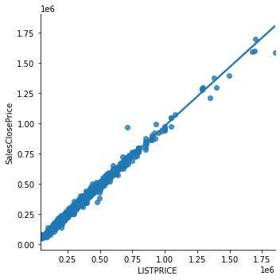

```python
# Your code goes here
sns.lmplot(x="LISTPRICE", y="SalesClosePrice", data=df)
```

From the plot it is evident that there is a linear relationship between the two variables as the list price is often times set with professionals. We have two many data points and it is hard to draw a conclusion from this chart. Let's take a different path: we will find the percentage difference between these two variables and plot its histogram. It should give us a better understanding of the relationship.

We can start with calculating this percentage difference, something like this:

```
(df['SalesClosePrice'] - df['LISTPRICE'])/df['LISTPRICE'] * 100
```

Let's assign the result to a variable called `sales_vs_list`:

```python
# Your code goes here
sales_vs_list = (df['SalesClosePrice'] - df['LISTPRICE'])/df['LISTPRICE'] * 100
```

```python
type(sales_vs_list)
```

```
pandas.core.series.Series
```

From the type of this object it is clear that this resulted in a pandas Series object. Series are one-dimensional ndarray with axis labels. Series is the datastructure for a single column of a DataFrame, not only conceptually, but literally, i.e. the data in a DataFrame is actually stored in memory as a collection of Series.

Now that we have our `sales_vs_list` ready let's try to answer our question.

First, use the `describe()` method on `sales_vs_list` to get the statistics summary (similar to DataFrame):

```python
# Your code goes here
sales_vs_list.describe()
```

```
count    5000.000000
mean        0.091693
std         4.514791
min       -32.584270
25%        -1.937002
50%         0.000000
75%         2.000000
max       100.000000
dtype: float64
```

A positive `sales_vs_list` value means that the house was sold above the list price and a negative means the opposite. With a 0 median it looks like as many houses were sold above the list price as below. But let's look at the histogram to get a better picture.

Use seaborn's `distplot()` to plot a histogram. All you need to do is to pass our variable to it (remember this function is coming from seaborn so you will need to use `.` to access it from seaborn:

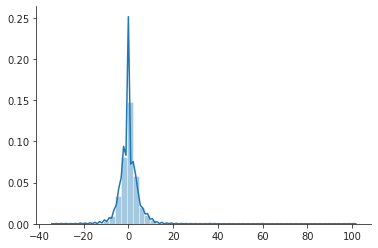

```python
# Your code goes here
sns.set_style("ticks")
sns.distplot(sales_vs_list)
sns.despine()
```

This is great, but let's make it even look nicer. You can set

```
sns.set_style("ticks")
```

to give a little extra structure to the plot. Go back to the previous plot and add that line before your plot. Note that you only need to do it once in the notebook and the style will carry for the following cells.

Another "stylish" change you can make is to remove the top and right axes spines, which are not needed. The seaborn function `despine()` can be called to remove them. It has to be called the line after the plot:

```
sns.despine()
```

To learn more about controlling figure aesthetics checkout [seaborn's documentation page](https://seaborn.pydata.org/tutorial/aesthetics.html).

Except some outliers it looks like the houses were sold within the 20% of the list price. We can checkout how many of these outliers are out there.

Filtering with Series is very similar to DataFrames; you can create a conditional such as `sales_vs_list > 20` and pass it to the original Series. Let's find all the instances where the house was sold more than 20% above the list price:

```python
# Your code goes here
sales_vs_list[sales_vs_list > 20]
```

```
1028    100.000000
1031     60.008000
1037     36.060100
1107     38.775510
1468     20.772947
2115     21.664814
4983     35.747711
dtype: float64
```

Okay, that long tail represent only 7 datapoints. Can you re-draw the histogram excluding the values above 20 and below -20?

This time use `kde=False` to ignore the gaussian kernel density estimate, use `bins=30` to include 30 bins, and specify `color="green"` for a change:

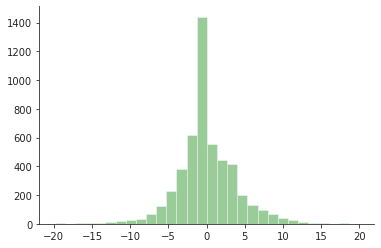

```python
# Your code goes here
sns.distplot((sales_vs_list[(sales_vs_list < 20) & (sales_vs_list > -20)]), kde=False, bins=30, color="green")
sns.despine()
```

Can you find how many of the houses were sold within 1% of the list price?

```python
# Your code goes here
len(sales_vs_list[abs(sales_vs_list) < 1])
```

```
1699
```

What percentage of overall dataset does it translate to?

```python
# Your code goes here
len(sales_vs_list[abs(sales_vs_list) < 1])/len(sales_vs_list)*100
```

```
33.98
```

Now that we are a pro in plotting histograms let's go back to our `df` DataFrame and plot the histogram of `SalesClosePrice`.

Note that in the plot below I have used `.set_title("Distribution of Closing Price")` from `matplotlib` to assign a title. Just append that to the rest of your code. You will have to import the package: `import matplotlib.pyplot as plt`

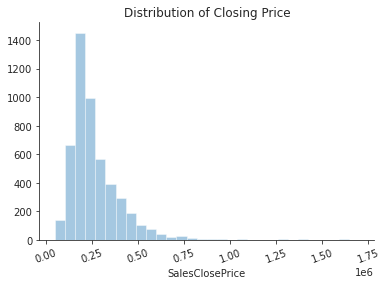

```python
# Your code goes here
import matplotlib.pyplot as plt
sns.distplot(df['SalesClosePrice'], kde=False, bins=30)
plt.xticks(rotation=20)
plt.title("Distribution of Closing Price")
sns.despine()
```

Note: seaborn is built on top of matplotlib. This means that we can use matplotlib's functions along with it. For instance in the above plot I have used the followings to format my graph:

```
plt.xticks(rotation=20)
plt.title("Distribution of Closing Price")
```

You still need to `import matplotlib.pyplot as plt`.

You can also use a violin plot to show the distribution. Violin plot is similar to a box plot, with the addition of a rotated kernel density plot on each side. We can simply use `sns.violinplot()` and pass `data` and `y` (or `x` depending on which direction you want the violin to be plotted).

Draw a violin plot using `SalesClosePrice`:

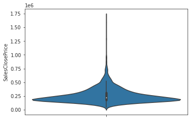

```python
# Your code goes here
sns.violinplot(y="SalesClosePrice", data=df)
```

Repeat the previous plot with the difference of adding an `x` variable, `SchoolDistrictNumber` to create a violin plot per category:

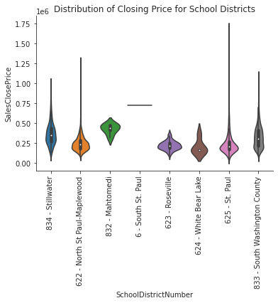

```python
# Your code goes here
sns.violinplot(x="SchoolDistrictNumber", y="SalesClosePrice", data=df)
plt.xticks(rotation=90)
plt.title("Distribution of Closing Price for School Districts")
sns.despine()
```

Try this with `x="City"`:

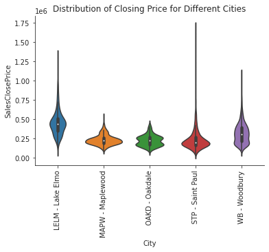

```python
# Your code goes here
sns.violinplot(x="City", y="SalesClosePrice", data=df)
plt.xticks(rotation=90)
plt.title("Distribution of Closing Price for Different Cities")
sns.despine()
```

## Handling Missing Vlaues

How many missing values are in `RoomArea1` column?

```python
# Your code goes here
print("There are {} missing values in RoomArea1".format(df['RoomArea1'].isnull().sum()))
```

```
There are 457 missing values in RoomArea1
```

Create `df2` where all the records no `RoomArea1` entry are dropped. Check with `df2.info()` to confirm:

```python
# Your code goes here
df2 = df[df['RoomArea1'].notnull()]
```

```python
df2.info()
```

```
<class 'pandas.core.frame.DataFrame'>
Int64Index: 4543 entries, 0 to 4999
Data columns (total 18 columns):
streetaddress           4543 non-null object
STREETNAME              4543 non-null object
PostalCode              4543 non-null int64
StateOrProvince         4543 non-null object
City                    4543 non-null object
SchoolDistrictNumber    4543 non-null object
SalesClosePrice         4543 non-null int64
LISTDATE                4543 non-null object
offmarketdate           4543 non-null object
LISTPRICE               4543 non-null int64
LISTTYPE                4543 non-null object
OriginalListPrice       4543 non-null int64
PricePerTSFT            4543 non-null float64
DAYSONMARKET            4543 non-null int64
ROOF                    3902 non-null object
SQFTABOVEGROUND         4543 non-null int64
RoomArea1               4543 non-null object
YEARBUILT               4543 non-null int64
dtypes: float64(1), int64(7), object(10)
memory usage: 674.4+ KB
```

From the code below looks like **Asphalt Shingles** is the most commonly used roof in our dataset. Use that to replace the unknown roofs we have in our dataset.

WARNING: replacing NAs with another value is a common technique but has to be used with caution. For instance, the reason some of these properties don't have roofs could be because they are not buildings, in which case you might want to exclude them from your analysis, rather than keeping them and introducing values for their missing points.

```python
df.groupby('ROOF')['ROOF'].count().sort_values(ascending=False)
```

```
ROOF
Asphalt Shingles                                                1417
Asphalt Shingles, Age 8 Years or Less                            839
Asphalt Shingles, Age Over 8 Years                               643
Asphalt Shingles, Pitched, Age 8 Years or Less                   362
Asphalt Shingles, Pitched                                        292
                                                                ...
Flat, Tar/Gravel, Age Over 8 Years                                 1
Flat, Other                                                        1
Flat, Age Over 8 Years, Tile                                       1
Asphalt Shingles, Pitched, Flat, Age 8 Years or Less, Rubber       1
Wood Shingles                                                      1
Name: ROOF, Length: 73, dtype: int64
```

```python
# Your code goes here
df2[['ROOF']] = df2[['ROOF']].fillna("Asphalt Shingles")
```

```
/usr/local/lib/python3.6/dist-packages/pandas/core/frame.py:3509: SettingWithCopyWarning:
A value is trying to be set on a copy of a slice from a DataFrame.
Try using .loc[row_indexer,col_indexer] = value instead

See the caveats in the documentation: http://pandas.pydata.org/pandas-docs/stable/user_guide/indexing.html#returning-a-view-versus-a-copy
  self[k1] = value[k2]
```

```python
df2.info()
```

```
<class 'pandas.core.frame.DataFrame'>
Int64Index: 4543 entries, 0 to 4999
Data columns (total 18 columns):
streetaddress           4543 non-null object
STREETNAME              4543 non-null object
PostalCode              4543 non-null int64
StateOrProvince         4543 non-null object
City                    4543 non-null object
SchoolDistrictNumber    4543 non-null object
SalesClosePrice         4543 non-null int64
LISTDATE                4543 non-null object
offmarketdate           4543 non-null object
LISTPRICE               4543 non-null int64
LISTTYPE                4543 non-null object
OriginalListPrice       4543 non-null int64
PricePerTSFT            4543 non-null float64
DAYSONMARKET            4543 non-null int64
ROOF                    4543 non-null object
SQFTABOVEGROUND         4543 non-null int64
RoomArea1               4543 non-null object
YEARBUILT               4543 non-null int64
dtypes: float64(1), int64(7), object(10)
memory usage: 674.4+ KB
```